# Sparkify Project Workspace

## Introduction

It's critical for any service provider to survive if they can sense that some of their users are about to leave or cancel their service. In this project, we are provided with dataset contain logs recorded for every user-service interaction. We will talk about detail of the dataset in later section. Our mission is to build predictive models from the dataset we owned and to predict whether a specific user has intention to churn.

To achieve our goal, we apply Pyspark as the framework of our project. Pyspark is the Spark API for Python that works efficiently especially when dealing with large size data. With the help of Spark, we are able to build highly efficient and useful applications.

## Overview

Our goal is to use log dataset to build predictive model that predicts users intention to churn. In order to get best model. We would achieve it by analyzing some features from the dataset with Spark manipulation. Furthermore, we check that if the feature can separate churned and non-churned user effectively. Finally, we would use both f1_score and accuracy as metrics to evaluate our model because sometimes we would sacrifice one when trying to optimizing the other.

Well... Let's start the project

Blog Post of this project can be found here https://burgercewu.medium.com/never-lose-any-one-sparkify-user-churn-prediction-challenge-using-pyspark-7ab67ac080d4 Github Repository can be found here https://github.com/BurgerWu/Sparkify-Project

```python
# import pyspark libraries
from pyspark.sql import SparkSession
from pyspark.sql.functions import udf, array
from pyspark.sql.types import IntegerType, StringType, BooleanType, DateType, FloatType
import  pyspark.sql.functions as sql_func
from pyspark.sql.functions import isnan, count, when, col, desc, udf, sort_array, asc, avg, rank, mean, first, ceil, rand
from pyspark.sql.window import Window
from pyspark import SparkContext, SparkConf

#import Python libraries
import math
import re
import datetime
import numpy as np
import pandas as pd
import seaborn as sb
import matplotlib.pyplot as plt
import os

%matplotlib inline
```

```python
# create a Spark session with configuration
spark = SparkSession.builder \
    .config("spark.driver.memory", "16g") \
    .config("spark.executor.memory", "16g") \
    .appName('Sparkify') \
    .getOrCreate()

sc = spark.sparkContext
```

```python
import warnings
warnings.filterwarnings('ignore')
```

## Load and Clean Dataset

Let's load the dataset and clean print out the schema of it

```python
#Load the dataset and print schema
df = spark.read.json("medium-sparkify-event-data.json")
df.printSchema()
```

```
root
 |-- artist: string (nullable = true)
 |-- auth: string (nullable = true)
 |-- firstName: string (nullable = true)
 |-- gender: string (nullable = true)
 |-- itemInSession: long (nullable = true)
 |-- lastName: string (nullable = true)
 |-- length: double (nullable = true)
 |-- level: string (nullable = true)
 |-- location: string (nullable = true)
 |-- method: string (nullable = true)
 |-- page: string (nullable = true)
 |-- registration: long (nullable = true)
 |-- sessionId: long (nullable = true)
 |-- song: string (nullable = true)
 |-- status: long (nullable = true)
 |-- ts: long (nullable = true)
 |-- userAgent: string (nullable = true)
 |-- userId: string (nullable = true)
```

Let's drop duplicated rows and rows with invalid userId and sessionId

```python
#We drop dulicated rows
df = df.dropDuplicates()

#We drop rows with NAN userId and sessionId
df = df.filter(df["userId"] != np.nan)
df = df.filter(df["sessionId"] != np.nan)
df.count()
```

```
528005
```

We then calculate distince users and pages in our analysis

```python
#Number of unique users (by ID)
Num_Unique_Users = df.select('userId').distinct().count()
print("There are {} distinct users (by userID)".format(Num_Unique_Users))

#Number of different type of pages
Num_Unique_Pages = df.select('page').distinct().count()
print("There are {} distinct page types (by userID)".format(Num_Unique_Pages))
```

```
There are 448 distinct users (by userID)
There are 19 distinct page types (by userID)
```

# Exploratory Data Analysis

## Define Churn

We define churned users as user who had been to **Cancellation Confirmation** page. We also define upgrade and downgrade event when users visited **Submit Upgrade** or **Submit Downgrade** page.

```python
#Define churn as user ever been to Cancellation Confirmation page
cancel_churn = udf(lambda x: 1 if x == "Cancellation Confirmation" else 0, IntegerType())
df = df.withColumn("Cancel", cancel_churn("page"))

#Define downgrade as user ever been to Submit Downgrade page
downgrade_churn = udf(lambda x: 1 if x == "Submit Downgrade" else 0, IntegerType())
df = df.withColumn("Downgrade", downgrade_churn("page"))

#Define upgrade as user ever been to Submit Upgrade page
upgrade_churn = udf(lambda x: 1 if x == "Submit Upgrade" else 0, IntegerType())
df = df.withColumn("Upgrade", upgrade_churn("page"))
```

## Create User Time Span

Because some of our variable would be analyzed on a daily basis, we create a time span column that records the time length between first and last log message.

```python
#Define window for time span calculation
windowSpec  = Window.partitionBy("userId")

#Create new column containing time span in days
df = df.withColumn("Time-Span", ceil((sql_func.max(col('ts')).over(windowSpec) - sql_func.min(col('ts')).over(windowSpec))/86400000))
```

## Explore Data

Once you've defined churn, perform some exploratory data analysis to observe the behavior for users who stayed vs users who churned. You can start by exploring aggregates on these two groups of users, observing how much of a specific action they experienced per a certain time unit or number of songs played.

### General Population Exploration

Here we try to analyze all the data recorded

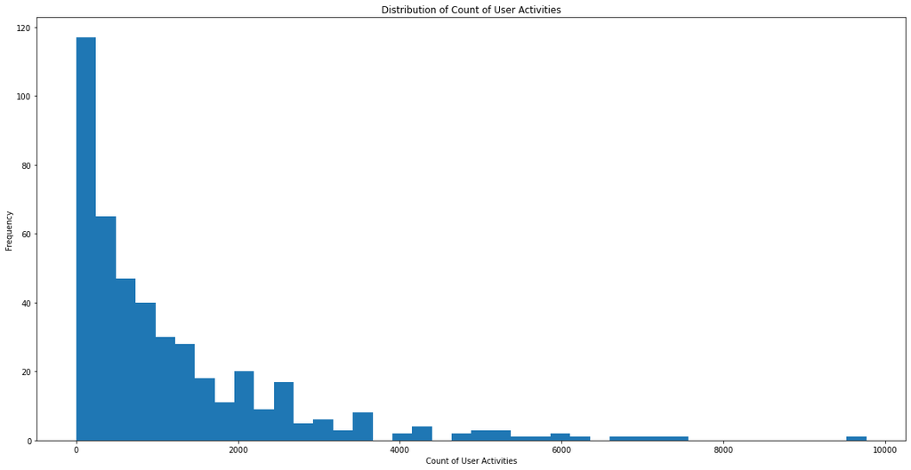

```python
#Plot count of user activities recorded in our dataset
user_count = df.groupBy('userId').count().orderBy("count").toPandas()
plt.figure(figsize = [20,10])
plt.hist(user_count['count'], bins = 40)
plt.xlabel("Count of User Activities")
plt.ylabel("Frequency")
plt.title("Distribution of Count of User Activities")
```

The distribution of user activities count is apparently right-skewed.

### Activities by Page Type

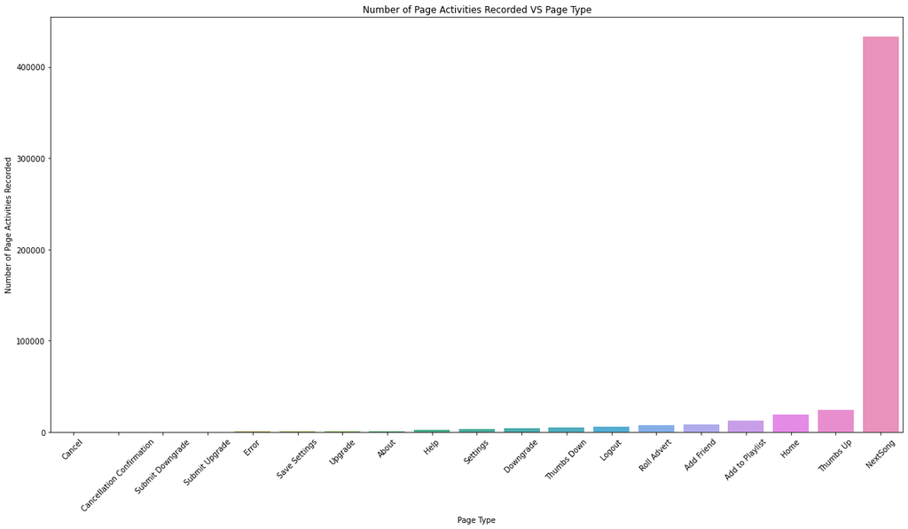

```python
#Plot number of page activities recorded by page type
page_count = df.groupBy('page').count().sort("count", ascending = True).toPandas()
plt.figure(figsize = [20,10])
sb.barplot(x = 'page', y = 'count', data = page_count)
plt.xticks(rotation = 45)
plt.xlabel("Page Type")
plt.ylabel("Number of Page Activities Recorded")
plt.title("Number of Page Activities Recorded VS Page Type")
```

The page that has most interactions with users is NextSong

### User Gender

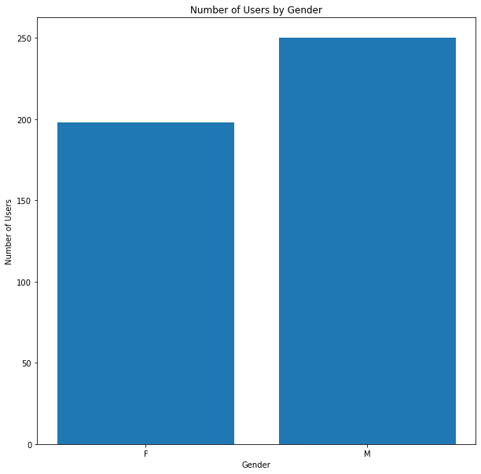

```python
#Plot number of users by gender
gender_count = df.select(['gender','userId']).distinct().groupBy('gender').count().toPandas()
plt.figure(figsize = [10,10])
plt.bar(gender_count['gender'], gender_count['count'])
plt.xlabel("Gender")
plt.ylabel("Number of Users")
plt.title("Number of Users by Gender")
```

Number of male users is slightly more than female users

### Location

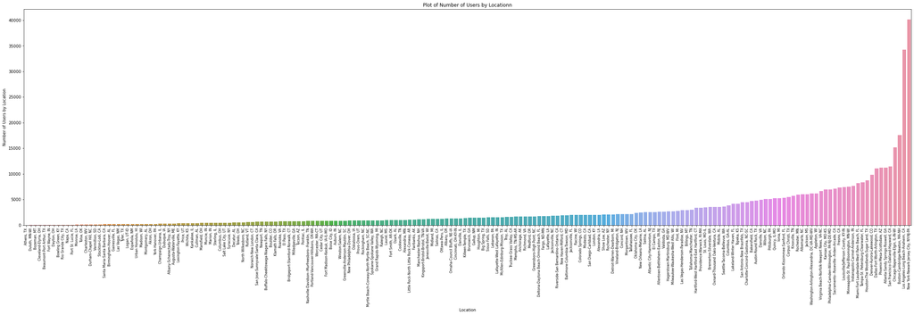

```python
#Plot number of users by location
location_count = df.groupBy('location').count().orderBy("count").toPandas()
plt.figure(figsize = [40,10])
sb.barplot(x = 'location', y = 'count', data = location_count)
plt.xticks(rotation = 90, fontsize=8)
plt.xlabel("Location")
plt.ylabel("Number of Users by Location")
plt.title("Plot of Number of Users by Locationn")
```

The top three cities that most users come from are New York, Los Angeles and Boston

### Most Listened to Artist

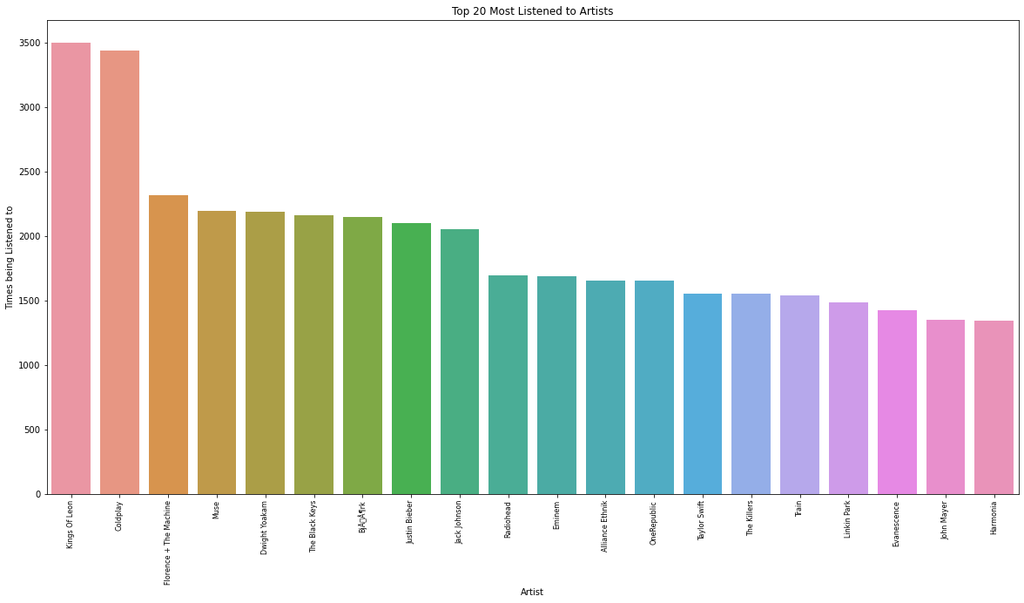

```python
#Groupby artist to get most listened to artist
artist = df.groupBy('artist').count().sort('count', ascending = False).toPandas()
artist = artist.dropna()
artist = artist.iloc[:20,:]

#Plot the result of most listened to artist using barplot
plt.figure(figsize = [20,10])
sb.barplot(x = 'artist', y = 'count', data = artist)
plt.xticks(rotation = 90, fontsize=8)
plt.xlabel("Artist")
plt.ylabel("Times being Listened to")
plt.title("Top 20 Most Listened to Artists")
```

The most listened to artists in our log period is King of Leon

### Most Listened to Songs

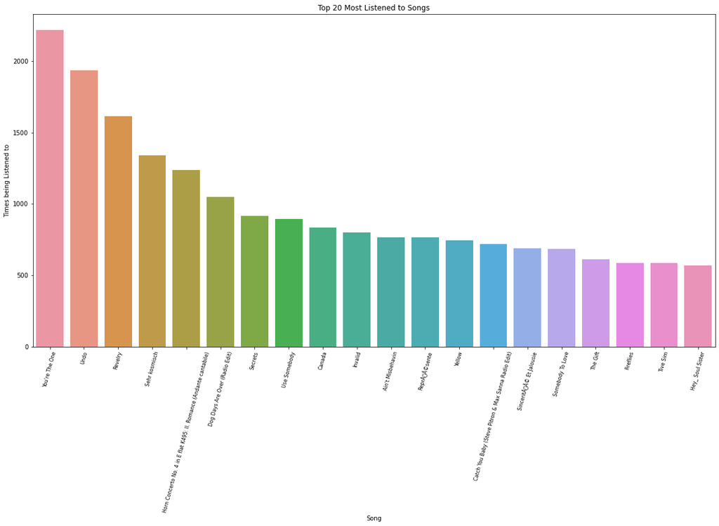

```python
#We groupby songs to filter out most listened to songs
songs = df.groupBy('song').count().sort('count', ascending = False).toPandas()
songs = songs.dropna()
songs = songs.iloc[:20,:]

#We plot the barplot of 20 most listened songs
plt.figure(figsize = [20,10])
sb.barplot(x = 'song', y = 'count', data = songs)
plt.xticks(rotation = 75, fontsize=8)
plt.xlabel("Song")
plt.ylabel("Times being Listened to")
plt.title("Top 20 Most Listened to Songs")
```

The top hit in our log priod is You're the One

### Exploration by Churned User

We first do some interesting things

```python
#Find out number of churned users
num_churn_user = df.filter(df['Cancel'] == 1).groupBy('userId').count().count()

#Print our observation
print("There are {} churned (Cancellation) users, the ratio of churned users is {}".format(num_churn_user, num_churn_user/Num_Unique_Users))
```

```
There are 99 churned (Cancellation) users, the ratio of churned users is 0.22098214285714285
```

```python
#Create user table that check if  user has ever churned
churned_users_table = df.groupBy('userId').agg(sql_func.max('Cancel').alias('Churned'))
churned_users = list(churned_users_table.filter(churned_users_table['Churned'] == 1).select('userId').toPandas()['userId'])

#Define udf to transform user churn state
churn_or_not = udf(lambda x: 1 if x in churned_users else 0, IntegerType())
df = df.withColumn('Churned', churn_or_not('userId'))
```

### Times of Downgrade V.S Churned or Not

The next task is to analyze how many times users downgrade by churned users or not.

```python
#We first calculate user downgrade time and then the ratio of times per user in that churn group
user_Downgrade_Times = df.groupBy(['userId','Churned']).sum('Downgrade').groupBy(['Churned','sum(Downgrade)']).count().toPandas()
user_Downgrade_Times.loc[user_Downgrade_Times['Churned'] == 1,'count'] /= num_churn_user
user_Downgrade_Times.loc[user_Downgrade_Times['Churned'] == 0,'count'] /= (Num_Unique_Users - num_churn_user)
```

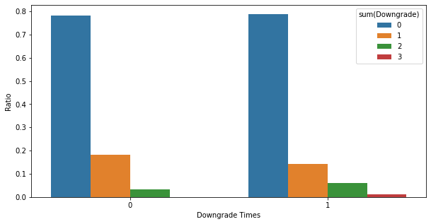

```python
#Next, we plot the result using barplot
plt.figure(figsize = [10, 5])
churn_downgrade_bar = sb.barplot(x = 'Churned', y = 'count', data = user_Downgrade_Times, hue = 'sum(Downgrade)')
plt.ylabel('Ratio')
plt.xlabel('Downgrade Times')
h, l = churn_downgrade_bar.get_legend_handles_labels()
#churn_downgrade_bar.legend(h, ['Not Churned User', 'Churned User'], title='Churned?', loc = 'upper right')
```

The downgrade behavior between churned and non churne user does not have sigficant difference except for some extreme values in churned user group

### Times of Upgrade V.S Churned or Not

The next task is to analyze how many times users upgrade by churned users or not.

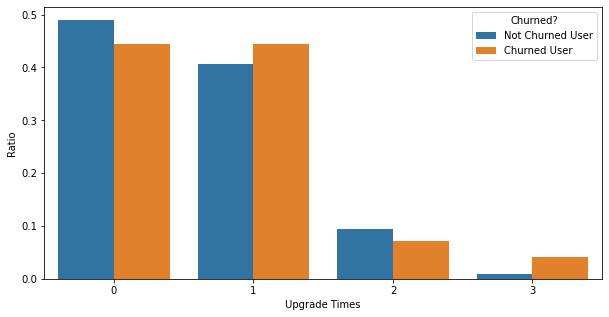

```python
#We first calculate user upgrade times and then the ratio of times per user in that churn group
user_Upgrade_Times = df.groupBy(['userId','Churned']).sum('Upgrade').groupBy(['Churned','sum(Upgrade)']).count().toPandas()
user_Upgrade_Times.loc[user_Upgrade_Times['Churned'] == 1,'count'] /= num_churn_user
user_Upgrade_Times.loc[user_Upgrade_Times['Churned'] == 0,'count'] /= (Num_Unique_Users - num_churn_user)

#Next, we plot the result using barplot
plt.figure(figsize = [10, 5])
churn_Upgrade_bar = sb.barplot(x = 'sum(Upgrade)', y = 'count', data = user_Upgrade_Times, hue = 'Churned')
plt.ylabel('Ratio')
plt.xlabel('Upgrade Times')
h, l = churn_Upgrade_bar.get_legend_handles_labels()
churn_Upgrade_bar.legend(h, ['Not Churned User', 'Churned User'], title='Churned?', loc = 'upper right')
```

The ratio of upgrade times dose not seem to be have significant difference between churned and non churned user.

### Final Level

In this cell, we try to figure out the final level when users decide to cancel the service

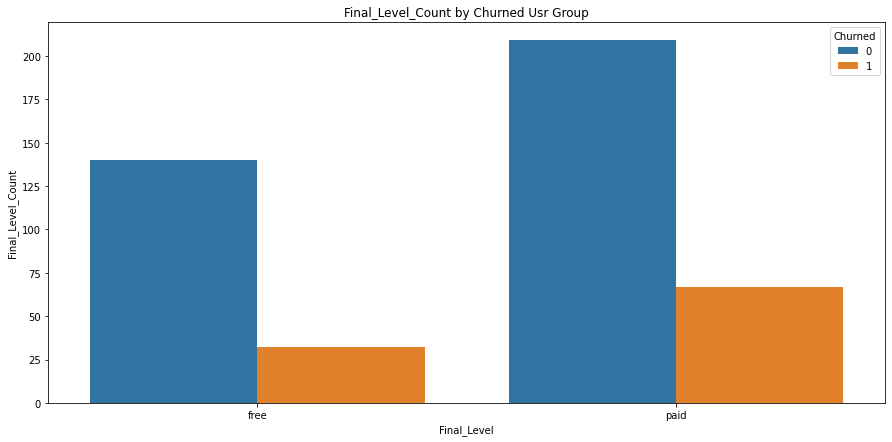

```python
#Create dataframe of final level of churned user
final_level = df.orderBy(['userId','ts'],ascending = False).groupBy(['userId','Churned']).agg(first('level').alias('Final_Level'))
final_level_pd = final_level.groupBy(['Churned','Final_Level']).agg(count('Final_Level').alias("Final_Level_Count")).toPandas()
final_level = final_level.drop('Churned')

#Plot our result
plt.figure(figsize = [15, 7])
sb.barplot(x = final_level_pd['Final_Level'], y = final_level_pd["Final_Level_Count"], hue = final_level_pd['Churned'])
plt.title('Final_Level_Count by Churned Usr Group')
```

```python
temp_table = final_level_pd.groupby('Final_Level').sum()[['Final_Level_Count']]
temp_table.columns = ['Total Amount by Level']
final_level_pd = final_level_pd.join(temp_table, on = 'Final_Level', rsuffix='')
final_level_pd['Ratio By Level'] = final_level_pd['Final_Level_Count'] / final_level_pd['Total Amount by Level']
final_level_pd = final_level_pd[['Churned', 'Final_Level', 'Final_Level_Count', 'Ratio By Level']]
final_level_pd
```

|  | Churned | Final_Level | Final_Level_Count | Ratio By Level |
| --- | --- | --- | --- | --- |
| 0 | 0 | free | 140 | 0.813953 |
| 1 | 0 | paid | 209 | 0.757246 |
| 2 | 1 | paid | 67 | 0.242754 |
| 3 | 1 | free | 32 | 0.186047 |

Higher proportion of paid user churned

### Total Time Spent

```
The mean value of total time spent for churned user groups are:
Churned Users: 212170.54003050513
Non-Churned Users: 248241.5457473925
```

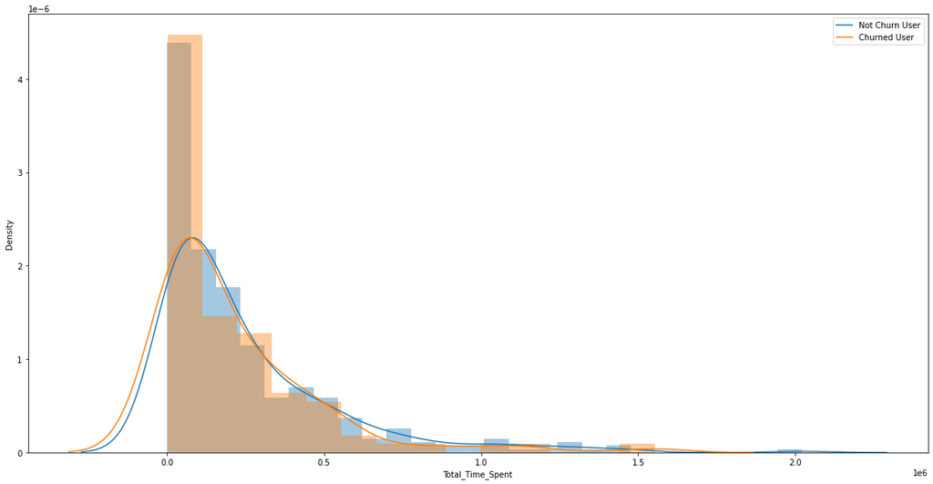

```python
total_time = df.groupBy(['userId','Churned']).agg(sql_func.sum('length').alias('Total_Time_Spent'))
total_time_pd = total_time.toPandas()
total_time = total_time.drop('Churned','Time-Span')

#Plot our result to check average session length of different churned user group
plt.figure(figsize = [20,10])
sb.distplot(total_time_pd[total_time_pd['Churned'] == 0]['Total_Time_Spent'])
sb.distplot(total_time_pd[total_time_pd['Churned'] == 1]['Total_Time_Spent'])
plt.legend(['Not Churn User','Churned User'])

#Print out textual conclusion of our result
totaltime_per_day_nonchurn = total_time_pd[total_time_pd['Churned'] == 0]['Total_Time_Spent'].mean()
totaltime_per_day_churn = total_time_pd[total_time_pd['Churned'] == 1]['Total_Time_Spent'].mean()
print("The mean value of total time spent for churned user groups are:\nChurned Users: {}\nNon-Churned Users: {}".format(totaltime_per_day_churn,totaltime_per_day_nonchurn))
```

According to out statistics, it seems on average more time was spent on our service for non churned users. But the kde distribution is not so different.

### Total Songs

```
The mean value of total songs for churned user groups are:
Churned Users: 852.1111111111111
Non-Churned Users: 998.6189111747851
```

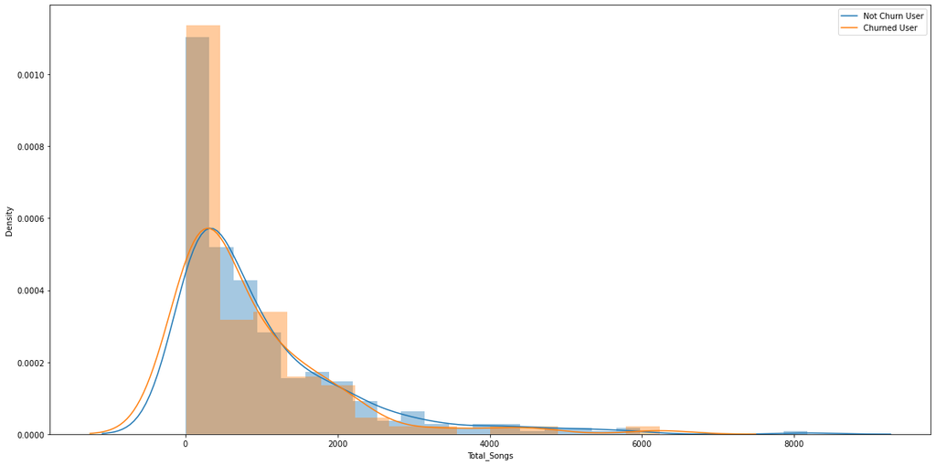

```python
total_songs = df.filter((df['song'].isNotNull())&(df['page'] == 'NextSong')).groupBy(['userId','Churned']).agg(count('page').alias('Total_Songs'))
total_songs_pd = total_songs.toPandas()
total_songs = total_songs.drop('Churned')

#Plot our result
plt.figure(figsize = [20,10])
sb.distplot(total_songs_pd[total_songs_pd['Churned'] == 0]['Total_Songs'])
sb.distplot(total_songs_pd[total_songs_pd['Churned'] == 1]['Total_Songs'])
plt.legend(['Not Churn User','Churned User'])

#Print out textual conclusion of our result
totalsongs_per_day_nonchurn = total_songs_pd[total_songs_pd['Churned'] == 0]['Total_Songs'].mean()
totalsongs_per_day_churn = total_songs_pd[total_songs_pd['Churned'] == 1]['Total_Songs'].mean()
print("The mean value of total songs for churned user groups are:\nChurned Users: {}\nNon-Churned Users: {}".format(totalsongs_per_day_churn,totalsongs_per_day_nonchurn))
```

Also, non churned users listened to more songs compared to churned users on average. But the kde distribution is not so different, either.

### Sessions per Month

```
The mean value of sessions per month by churned user groups are:
Churned Users: 18.01652834887248
Non-Churned Users: 9.446132999529809
```

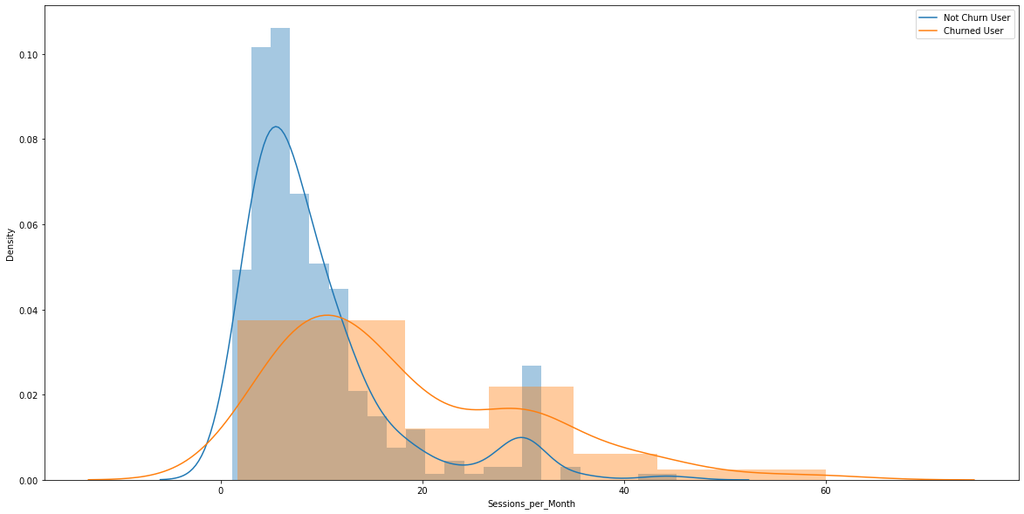

```python
#Create unique songs by user group dataframe
session_month_user = df.groupBy(['userId','Churned','Time-Span','sessionId']).count().groupBy(['userId','Churned','Time-Span']).agg(count('sessionId').alias('Num_of_Sessions'))
session_month_user = session_month_user.withColumn('Sessions_per_Month', col("Num_of_Sessions")/col('Time-Span')*30)
session_month_user_pd = session_month_user.toPandas()
session_month_user = session_month_user.drop('Churned',"Num_of_Sessions",'Time-Span')

#Plot our result to check average session length of different churned user group
plt.figure(figsize = [20,10])
sb.distplot(session_month_user_pd[session_month_user_pd['Churned'] == 0]['Sessions_per_Month'])
sb.distplot(session_month_user_pd[session_month_user_pd['Churned'] == 1]['Sessions_per_Month'])
plt.legend(['Not Churn User','Churned User'])

#Print out textual conclusion of our result
session_month_user_nonchurn = session_month_user_pd[session_month_user_pd['Churned'] == 0]['Sessions_per_Month'].mean()
session_month_user_churn = session_month_user_pd[session_month_user_pd['Churned'] == 1]['Sessions_per_Month'].mean()
print("The mean value of sessions per month by churned user groups are:\nChurned Users: {}\nNon-Churned Users: {}".format(session_month_user_churn, session_month_user_nonchurn))
```

The mean value of sessions per month is much higher for churned user group and kde distribution differs a lot, too.

### Average Session Length Analysis

```
The mean value of average session length for churned user groups are:
Churned Users: 17693.5059183909
Non-Churned Users: 15907.96067304279
```

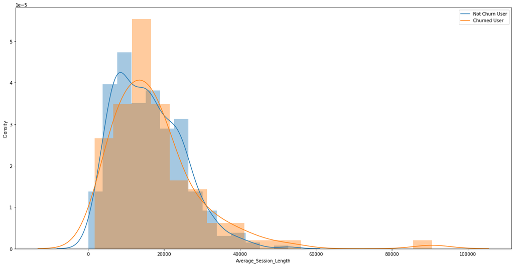

```python
#Apply groupby to find out averge session length of users
avg_session_length_user = df.groupBy(['userId','Churned',"sessionId"]).sum('length').groupBy(['userId','Churned']).agg(avg('sum(length)').alias('Average_Session_Length'))
avg_session_length_user_pd = avg_session_length_user.toPandas()
avg_session_length_user = avg_session_length_user.drop('Churned')

#Plot our result
plt.figure(figsize = [20,10])
sb.distplot(avg_session_length_user_pd[avg_session_length_user_pd['Churned'] == 0]['Average_Session_Length'])
sb.distplot(avg_session_length_user_pd[avg_session_length_user_pd['Churned'] == 1]['Average_Session_Length'])
plt.legend(['Not Churn User','Churned User'])


#Print out textual conclusion of our result
session_length_nonchurn = avg_session_length_user_pd[avg_session_length_user_pd['Churned'] == 0]['Average_Session_Length'].mean()
session_length_churn = avg_session_length_user_pd[avg_session_length_user_pd['Churned'] == 1]['Average_Session_Length'].mean()
print("The mean value of average session length for churned user groups are:\nChurned Users: {}\nNon-Churned Users: {}".format(session_length_churn,session_length_nonchurn))
```

### User Device Exploration

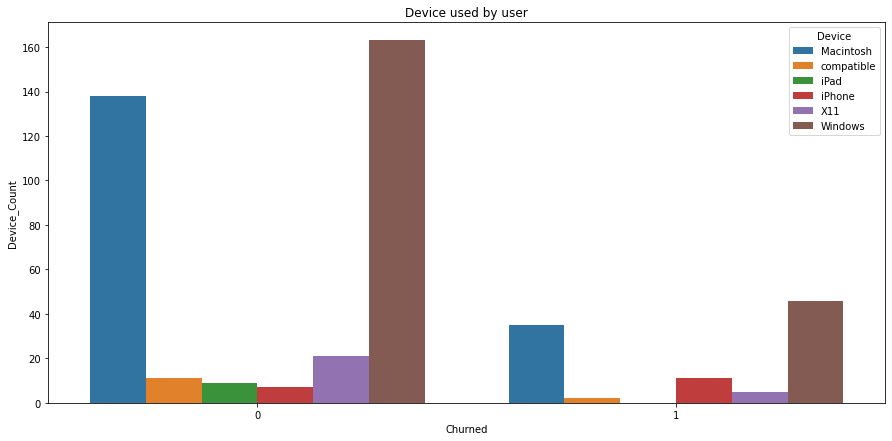

```python
def extract_device(col):
    """
    This function extraction device from column text

    Input: Text content of the column
    Output: Device name
    """
    device = re.findall(r'\([a-zA-Z0-9]*',col)[0].strip()[1:]
    return device

#Define user-defined device extraction function
get_device = udf(extract_device, StringType())

#Create new column as device
df = df.withColumn('Device', get_device('userAgent'))

#Create dataframe containing information of device of churned user groups
device_user = df.groupBy(['userId','Churned']).agg(first('Device').alias('Device'))
device_user_pd = device_user.groupBy(['Churned','Device']).agg(count('Device').alias('Device_Count')).toPandas()
device_user = device_user.drop('Churned')

#Plot the result
plt.figure(figsize = [15, 7])
sb.barplot(x = device_user_pd['Churned'], y = device_user_pd['Device_Count'], hue = device_user_pd['Device'])
plt.title('Device used by user')
```

```python
temp_table = device_user_pd.groupby('Device').sum()[['Device_Count']]
temp_table.columns = ['Total Amount by Device']
device_user_pd = device_user_pd.join(temp_table, on = 'Device', rsuffix='')
device_user_pd['Ratio By Device'] = device_user_pd['Device_Count'] / device_user_pd['Total Amount by Device']
device_user_pd = device_user_pd[['Churned', 'Device', 'Device_Count', 'Ratio By Device']]

device_user_pd.sort_values(by = 'Device')
```

|  | Churned | Device | Device_Count | Ratio By Device |
| --- | --- | --- | --- | --- |
| 0 | 1 | Macintosh | 35 | 0.202312 |
| 10 | 0 | Macintosh | 138 | 0.797688 |
| 8 | 1 | Windows | 46 | 0.220096 |
| 9 | 0 | Windows | 163 | 0.779904 |
| 4 | 0 | X11 | 21 | 0.807692 |
| 7 | 1 | X11 | 5 | 0.192308 |
| 1 | 0 | compatible | 11 | 0.846154 |
| 6 | 1 | compatible | 2 | 0.153846 |
| 2 | 0 | iPad | 9 | 1.000000 |
| 3 | 0 | iPhone | 7 | 0.388889 |
| 5 | 1 | iPhone | 11 | 0.611111 |

Two major platform that our users use are Macintosh and Windows. But the ratio of churn is not different from population.

### Total Thumbs Up Given

```
The amount of thumbs up for churned user groups are:
Churned Users: 43.87755102040816
Non-Churned Users: 57.26099706744868
```

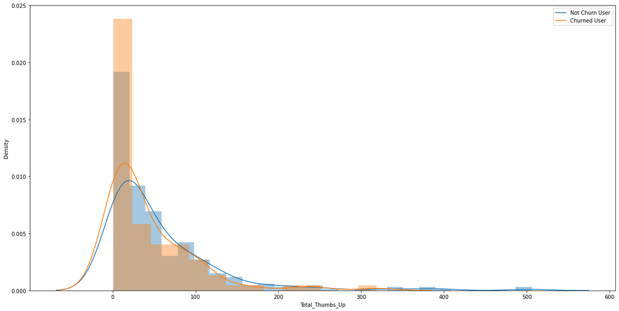

```python
#Create unique songs by user gorup dataframe
thumbs_up_user = df.filter(df['page'] == 'Thumbs Up').groupBy(['userId','Churned']).agg(count('page').alias('Total_Thumbs_Up'))
thumbs_up_user_pd = thumbs_up_user.toPandas()
thumbs_up_user = thumbs_up_user.drop('Churned')

#Plot our result
plt.figure(figsize = [20,10])
sb.distplot(thumbs_up_user_pd[thumbs_up_user_pd['Churned'] == 0]['Total_Thumbs_Up'])
sb.distplot(thumbs_up_user_pd[thumbs_up_user_pd['Churned'] == 1]['Total_Thumbs_Up'])
plt.legend(['Not Churn User','Churned User'])


#Print out textual conclusion of our result
thumbs_up_nonchurn = thumbs_up_user_pd[thumbs_up_user_pd['Churned'] == 0]['Total_Thumbs_Up'].mean()
thumbs_up_churn = thumbs_up_user_pd[thumbs_up_user_pd['Churned'] == 1]['Total_Thumbs_Up'].mean()
print("The amount of thumbs up for churned user groups are:\nChurned Users: {}\nNon-Churned Users: {}".format(thumbs_up_churn, thumbs_up_nonchurn))
```

It seems non churned users on average give much more thumbs up than non-churned users

### Thums Ups per Day

```
The mean value of thumbs up per day by churned user groups are:
Churned Users: 1.9393788021861678
Non-Churned Users: 1.148573307334694
```

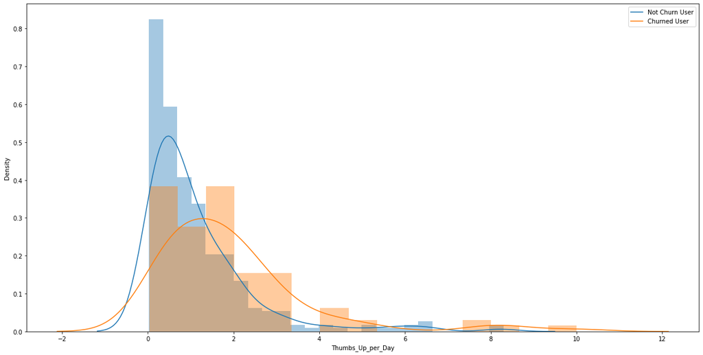

```python
#Create unique songs by user gorup dataframe
thumbs_up_day_user = df.filter(df['page'] == 'Thumbs Up').groupBy(['userId','Churned','Time-Span']).agg(count('page').alias('Thumbs_Up_Times'))
thumbs_up_day_user = thumbs_up_day_user.withColumn('Thumbs_Up_per_Day', col("Thumbs_Up_Times")/col('Time-Span'))
thumbs_up_day_user_pd = thumbs_up_day_user.toPandas()
thumbs_up_day_user = thumbs_up_day_user.drop('Churned','Thumbs_Up_Times','Time-Span')

#Plot our result
plt.figure(figsize = [20,10])
sb.distplot(thumbs_up_day_user_pd[thumbs_up_day_user_pd['Churned'] == 0]['Thumbs_Up_per_Day'])
sb.distplot(thumbs_up_day_user_pd[thumbs_up_day_user_pd['Churned'] == 1]['Thumbs_Up_per_Day'])
plt.legend(['Not Churn User','Churned User'])

#Print out textual conclusion of our result
thumbs_up_day_user_nonchurn = thumbs_up_day_user_pd[thumbs_up_day_user_pd['Churned'] == 0]['Thumbs_Up_per_Day'].mean()
thumbs_up_day_user_churn = thumbs_up_day_user_pd[thumbs_up_day_user_pd['Churned'] == 1]['Thumbs_Up_per_Day'].mean()
print("The mean value of thumbs up per day by churned user groups are:\nChurned Users: {}\nNon-Churned Users: {}".format(thumbs_up_day_user_churn, thumbs_up_day_user_nonchurn))
```

The mean value of thumbs up per day is higher for churned users and with very different distribution

### Total Thumbs Down Given

```
The amount of thumbs down for churned user grodowns are:
Churned Users: 12.98876404494382
Non-Churned Users: 12.516666666666667
```

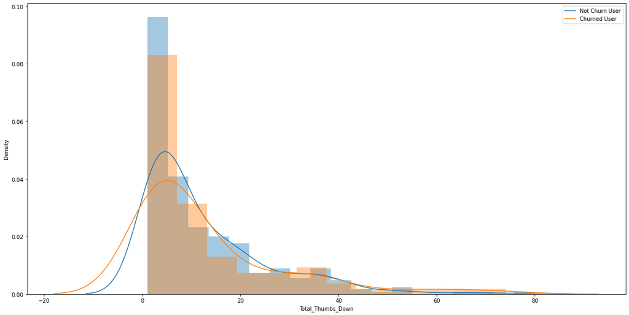

```python
#Create unique songs by user gordown dataframe
thumbs_down_user = df.filter(df['page'] == 'Thumbs Down').groupBy(['userId','Churned']).agg(count('page').alias('Total_Thumbs_Down'))
thumbs_down_user_pd = thumbs_down_user.toPandas()
thumbs_down_user = thumbs_down_user.drop('Churned')

#Plot our result
plt.figure(figsize = [20,10])
sb.distplot(thumbs_down_user_pd[thumbs_down_user_pd['Churned'] == 0]['Total_Thumbs_Down'])
sb.distplot(thumbs_down_user_pd[thumbs_down_user_pd['Churned'] == 1]['Total_Thumbs_Down'])
plt.legend(['Not Churn User','Churned User'])


#Print out textual conclusion of our result
thumbs_down_nonchurn = thumbs_down_user_pd[thumbs_down_user_pd['Churned'] == 0]['Total_Thumbs_Down'].mean()
thumbs_down_churn = thumbs_down_user_pd[thumbs_down_user_pd['Churned'] == 1]['Total_Thumbs_Down'].mean()
print("The amount of thumbs down for churned user grodowns are:\nChurned Users: {}\nNon-Churned Users: {}".format(thumbs_down_churn, thumbs_down_nonchurn))
```

If we check thumbs down in a aggregation manner, no obvious difference is observed.

### Thumbs Down per Day

```
The mean value of thumbs down per day by churned user grodowns are:
Churned Users: 0.5353901355462914
Non-Churned Users: 0.25911445997081517
```

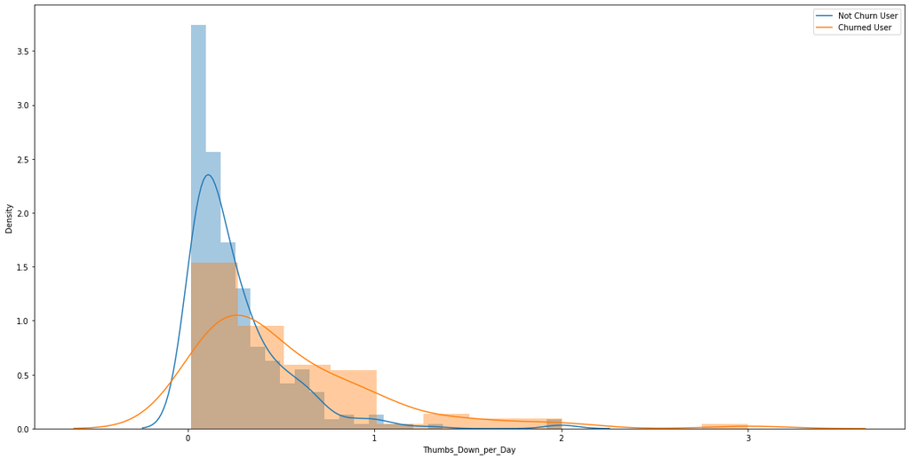

```python
#Create unique songs by user gordown dataframe
thumbs_down_day_user = df.filter(df['page'] == 'Thumbs Down').groupBy(['userId','Churned','Time-Span']).agg(count('page').alias('Thumbs_Down_Times'))
thumbs_down_day_user = thumbs_down_day_user.withColumn('Thumbs_Down_per_Day', col("Thumbs_Down_Times")/col('Time-Span'))
thumbs_down_day_user_pd = thumbs_down_day_user.toPandas()
thumbs_down_day_user = thumbs_down_day_user.drop('Churned','Thumbs_Down_Times','Time-Span')

#Plot our result to check average session length of different churned user grodown
plt.figure(figsize = [20,10])
sb.distplot(thumbs_down_day_user_pd[thumbs_down_day_user_pd['Churned'] == 0]['Thumbs_Down_per_Day'])
sb.distplot(thumbs_down_day_user_pd[thumbs_down_day_user_pd['Churned'] == 1]['Thumbs_Down_per_Day'])
plt.legend(['Not Churn User','Churned User'])

#Print out textual conclusion of our result
thumbs_down_day_user_nonchurn = thumbs_down_day_user_pd[thumbs_down_day_user_pd['Churned'] == 0]['Thumbs_Down_per_Day'].mean()
thumbs_down_day_user_churn = thumbs_down_day_user_pd[thumbs_down_day_user_pd['Churned'] == 1]['Thumbs_Down_per_Day'].mean()
print("The mean value of thumbs down per day by churned user grodowns are:\nChurned Users: {}\nNon-Churned Users: {}".format(thumbs_down_day_user_churn, thumbs_down_day_user_nonchurn))
```

But as we check from a daily manner, the mean for churned group is much higher.

### Thumbs Up Ratio

```
The average thumbs up ratio for churned user grodowns are:
Churned Users: 0.7854329675622295
Non-Churned Users: 0.8157294475241931
```

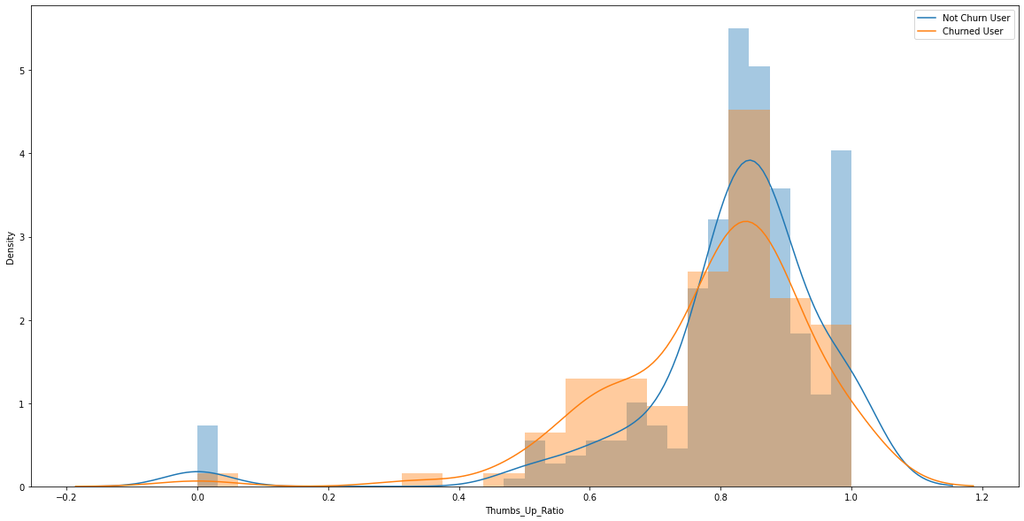

```python
thumbs_up_ratio = churned_users_table.join(thumbs_up_user, on = 'userId', how = 'left')
thumbs_up_ratio = thumbs_up_ratio.join(thumbs_down_user, on = 'userId', how = 'left')
thumbs_up_ratio = thumbs_up_ratio.fillna(0)
thumbs_up_ratio = thumbs_up_ratio.withColumn("Thumbs_Up_Ratio", col('Total_Thumbs_Up')/(col('Total_Thumbs_Down')+col('Total_Thumbs_Up')))
thumbs_up_ratio = thumbs_up_ratio.fillna(0)
thumbs_up_ratio_pd = thumbs_up_ratio.toPandas()
thumbs_up_ratio = thumbs_up_ratio.drop('Churned', 'Total_Thumbs_Up', 'Total_Thumbs_Down')

#Plot our result
plt.figure(figsize = [20,10])
sb.distplot(thumbs_up_ratio_pd[thumbs_up_ratio_pd['Churned'] == 0]['Thumbs_Up_Ratio'])
sb.distplot(thumbs_up_ratio_pd[thumbs_up_ratio_pd['Churned'] == 1]['Thumbs_Up_Ratio'])
plt.legend(['Not Churn User','Churned User'])

#Print out textual conclusion of our result
thumbs_up_ratio_nonchurn = thumbs_up_ratio_pd[thumbs_up_ratio_pd['Churned'] == 0]['Thumbs_Up_Ratio'].mean()
thumbs_up_ratio_churn = thumbs_up_ratio_pd[thumbs_up_ratio_pd['Churned'] == 1]['Thumbs_Up_Ratio'].mean()
print("The average thumbs up ratio for churned user grodowns are:\nChurned Users: {}\nNon-Churned Users: {}".format(thumbs_up_ratio_churn, thumbs_up_ratio_nonchurn))
```

As we explore the ratio of thumbs up, non-churned users seem to have higher thumbs up proportion

### Churn Gender Analysis

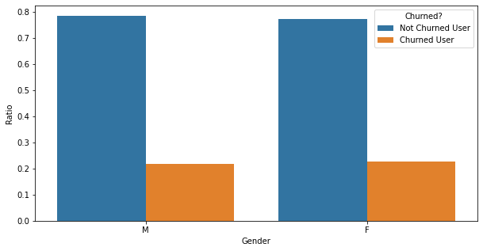

```python
#We create gender churn statistic by groupBy method
gender_user = df.groupBy(['userId','gender']).agg(sql_func.max('Cancel').alias("Churned"))
gender_churn_pd = gender_user.groupBy(['gender','Churned']).count().toPandas()
gender_user = gender_user.drop('Churned')

#Calculate number of male and female users
num_female = gender_churn_pd[gender_churn_pd['gender'] == 'F']['count'].sum()
num_male = gender_churn_pd[gender_churn_pd['gender'] == 'M']['count'].sum()

#Transform counts to ratio
gender_churn_pd.loc[gender_churn_pd['gender'] == 'F', 'count'] /= num_female
gender_churn_pd.loc[gender_churn_pd['gender'] == 'M', 'count'] /= num_male
gender_churn_pd.columns = ['gender', 'Churned', 'ratio']

#Plot results using barplot with hue Churned
plt.figure(figsize = [10, 5])
gender_churn_bar = sb.barplot(x = 'gender', y = 'ratio', data = gender_churn_pd, hue = 'Churned')
plt.ylabel('Ratio')
plt.xlabel('Gender')
h, l = gender_churn_bar.get_legend_handles_labels()
gender_churn_bar.legend(h, ['Not Churned User', 'Churned User'], title = 'Churned?', loc = 'upper right')
```

From our result, female users have slightly higher chance to churn than male users. But all close to population behavior

### Unique Songs by Churned User Group

```
The mean value of unique songs for churned user groups are:
Churned Users: 756.6161616161617
Non-Churned Users: 879.3782234957021
```

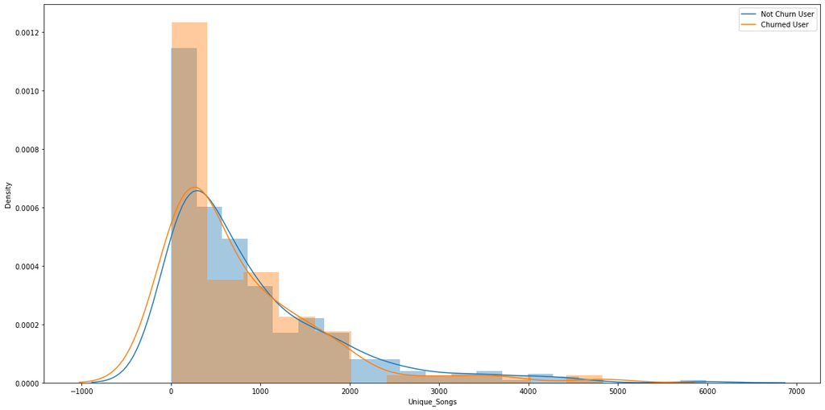

```python
#Create unique songs by user gorup dataframe
unique_songs_user = df.filter(df['song'].isNotNull()).dropDuplicates(subset = ['userId', 'Churned', 'song']).groupBy(['userId','Churned']).agg(count('song').alias('Unique_Songs'))
unique_songs_user_pd = unique_songs_user.toPandas()
unique_songs_user = unique_songs_user.drop('Churned')

#Plot our result
plt.figure(figsize = [20,10])
sb.distplot(unique_songs_user_pd[unique_songs_user_pd['Churned'] == 0]['Unique_Songs'])
sb.distplot(unique_songs_user_pd[unique_songs_user_pd['Churned'] == 1]['Unique_Songs'])
plt.legend(['Not Churn User','Churned User'])

#Print out textual conclusion of our result
unique_songs_nonchurn = unique_songs_user_pd[unique_songs_user_pd['Churned'] == 0]['Unique_Songs'].mean()
unique_songs_churn = unique_songs_user_pd[unique_songs_user_pd['Churned'] == 1]['Unique_Songs'].mean()
print("The mean value of unique songs for churned user groups are:\nChurned Users: {}\nNon-Churned Users: {}".format(unique_songs_churn, unique_songs_nonchurn))
```

On average, non churned users have much more unique song played according to our analysis.

### Unique Artists by Churned Group

```
The mean value of unique artists for churned user groups are:
Churned Users: 592.7373737373738
Non-Churned Users: 677.7707736389685
```

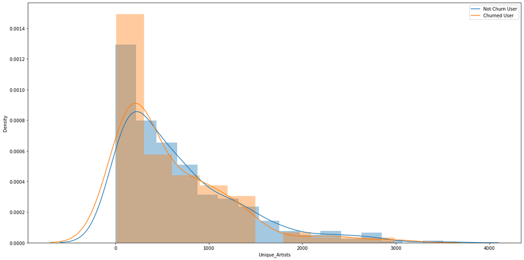

```python
#Create unique songs by user gorup dataframe
unique_artists_user = df.filter(df['artist'].isNotNull()).dropDuplicates(subset = ['userId', 'Churned', 'artist']).groupBy(['userId','Churned']).agg(count('artist').alias('Unique_Artists'))
unique_artists_user_pd = unique_artists_user.toPandas()
unique_artists_user = unique_artists_user.drop('Churned')

#Plot our result
plt.figure(figsize = [20,10])
sb.distplot(unique_artists_user_pd[unique_artists_user_pd['Churned'] == 0]['Unique_Artists'])
sb.distplot(unique_artists_user_pd[unique_artists_user_pd['Churned'] == 1]['Unique_Artists'])
plt.legend(['Not Churn User','Churned User'])

#Print out textual conclusion of our result
unique_artists_nonchurn = unique_artists_user_pd[unique_artists_user_pd['Churned'] == 0]['Unique_Artists'].mean()
unique_artists_churn = unique_artists_user_pd[unique_artists_user_pd['Churned'] == 1]['Unique_Artists'].mean()
print("The mean value of unique artists for churned user groups are:\nChurned Users: {}\nNon-Churned Users: {}".format(unique_artists_churn, unique_artists_nonchurn))
```

Similar to unique songs, non churned users seem to have more unique artists.

### Average Item in Session by Churned User Group

```
The mean value of avgerage item in session for churned user groups are:
Churned Users: 86.84265726520145
Non-Churned Users: 76.57598244111865
```

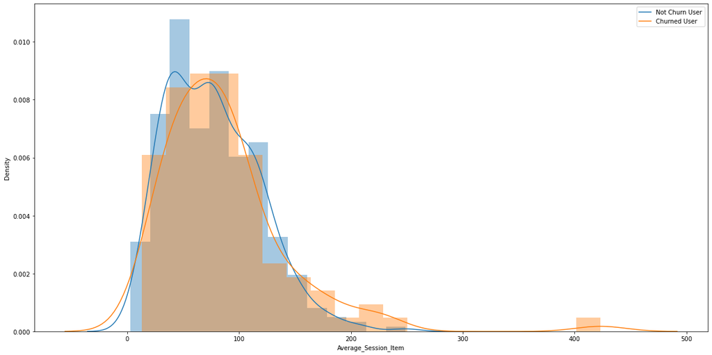

```python
##Create average items in session by user group dataframe
avg_item_session = df.groupBy(['userId','Churned','sessionId']).count().groupBy(['userId','Churned']).agg(avg('count').alias('Average_Session_Item'))
avg_item_session_pd = avg_item_session.toPandas()
avg_item_session = avg_item_session.drop('Churned')

#Plot our result
plt.figure(figsize = [20,10])
sb.distplot(avg_item_session_pd[avg_item_session_pd['Churned'] == 0]['Average_Session_Item'])
sb.distplot(avg_item_session_pd[avg_item_session_pd['Churned'] == 1]['Average_Session_Item'])
plt.legend(['Not Churn User','Churned User'])


#Print out textual conclusion of our result
avg_item_session_nonchurn = avg_item_session_pd[avg_item_session_pd['Churned'] == 0]['Average_Session_Item'].mean()
avg_item_session_churn = avg_item_session_pd[avg_item_session_pd['Churned'] == 1]['Average_Session_Item'].mean()
print("The mean value of avgerage item in session for churned user groups are:\nChurned Users: {}\nNon-Churned Users: {}".format(avg_item_session_churn, avg_item_session_nonchurn))
```

On average churned users have higher amount of items in session

### Total Friends by Churned User Group

```
The mean value of total friends for churned user groups are:
Churned Users: 16.178947368421053
Non-Churned Users: 20.85987261146497
```

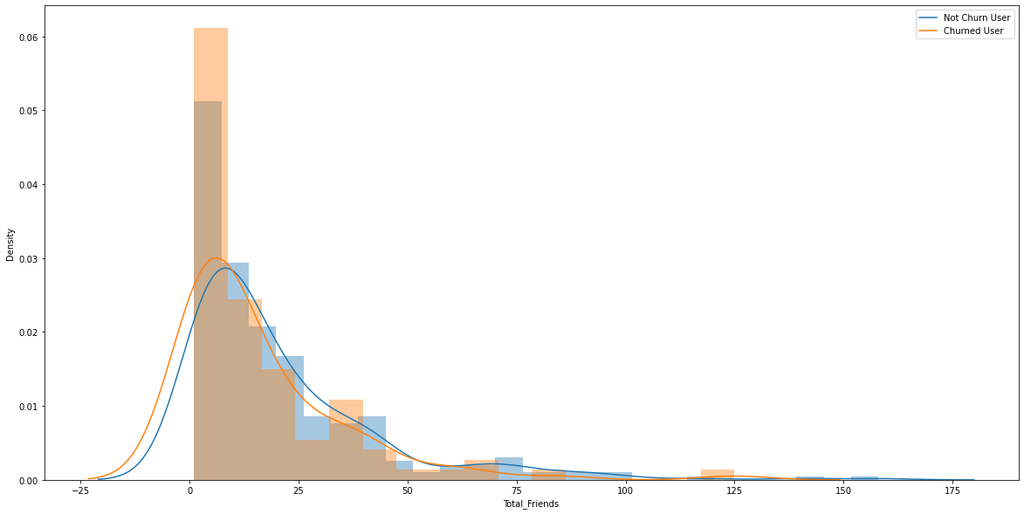

```python
#Create total friends of by user group dataframe
total_Friends = df.filter(df['page'] == 'Add Friend').groupBy(['userId','Churned']).agg(count('page').alias('Total_Friends'))
total_Friends_pd = total_Friends.toPandas()
total_Friends = total_Friends.drop('Churned')

#Plot our result
plt.figure(figsize = [20,10])
sb.distplot(total_Friends_pd[total_Friends_pd['Churned'] == 0]['Total_Friends'])
sb.distplot(total_Friends_pd[total_Friends_pd['Churned'] == 1]['Total_Friends'])
plt.legend(['Not Churn User','Churned User'])

#Print out textual conclusion of our result
total_Friends_nonchurn = total_Friends_pd[total_Friends_pd['Churned'] == 0]['Total_Friends'].mean()
total_Friends_churn = total_Friends_pd[total_Friends_pd['Churned'] == 1]['Total_Friends'].mean()
print("The mean value of total friends for churned user groups are:\nChurned Users: {}\nNon-Churned Users: {}".format(total_Friends_churn, total_Friends_nonchurn))
```

Non churned users tend to have more friends in our exploration

### Membership Duration

```
The mean value of membership duration for churned user groups are:
Churned Users: 67.9680198980546
Non-Churned Users: 87.04871421654472
```

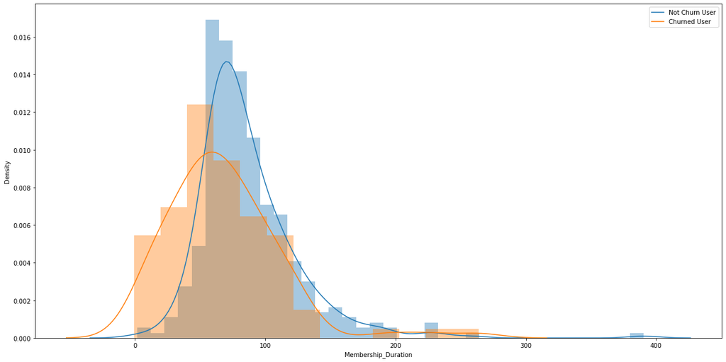

```python
register_user = df.orderBy(['userId','ts'], ascending = False).groupBy(['userId','Churned','registration']).agg(first('ts').alias("Last_Log_Time"))
register_user = register_user.withColumn('Membership_Duration', (col('Last_Log_Time')-col('registration'))/86400000)
register_user_pd = register_user.toPandas()
register_user = register_user.drop("Last_Log_Time","Churned","registration")

#Plot our result
plt.figure(figsize = [20,10])
sb.distplot(register_user_pd[register_user_pd['Churned'] == 0]['Membership_Duration'])
sb.distplot(register_user_pd[register_user_pd['Churned'] == 1]['Membership_Duration'])
plt.legend(['Not Churn User','Churned User'])

#Print out textual conclusion of our result
member_duration_nonchurn = register_user_pd[register_user_pd['Churned'] == 0]['Membership_Duration'].mean()
member_duration_churn = register_user_pd[register_user_pd['Churned'] == 1]['Membership_Duration'].mean()
print("The mean value of membership duration for churned user groups are:\nChurned Users: {}\nNon-Churned Users: {}".format(member_duration_churn, member_duration_nonchurn))
```

Non churned users tend to have longer membership duration.

### Errors per Day

```
The mean value of error day user encountered by churned user groups are:
Churned Users: 0.07911450098624193
Non-Churned Users: 0.04635279298064629
```

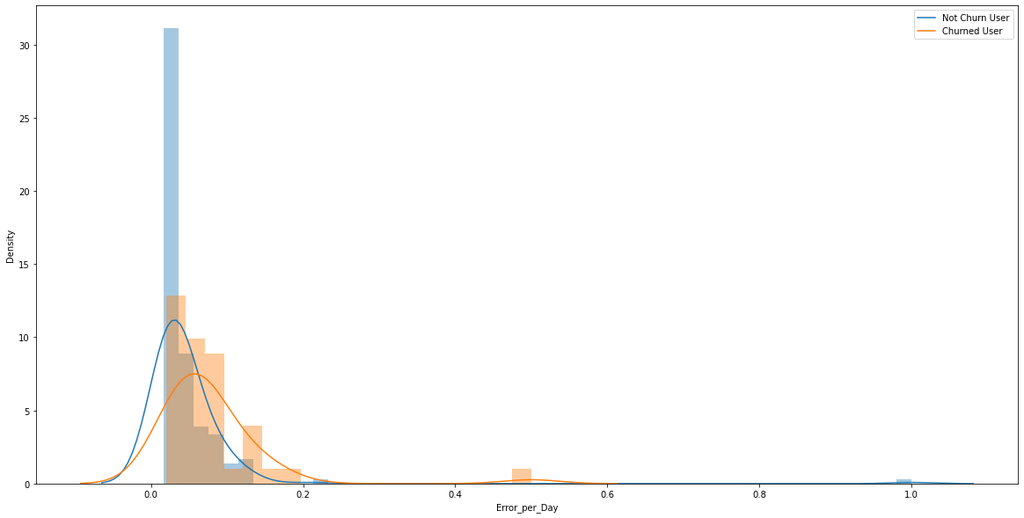

```python
#Create unique songs by user group dataframe
error_day_user = df.filter(df['page'] == 'Error').groupBy(['userId','Churned','Time-Span']).agg(count('page').alias('Error_Times'))
error_day_user = error_day_user.withColumn('Error_per_Day', col("Error_Times")/col('Time-Span'))
error_day_user_pd = error_day_user.toPandas()
error_day_user = error_day_user.drop('Churned','Error_Times','Time-Span')

#Plot our result to check average session length of different churned user group
plt.figure(figsize = [20,10])
sb.distplot(error_day_user_pd[error_day_user_pd['Churned'] == 0]['Error_per_Day'])
sb.distplot(error_day_user_pd[error_day_user_pd['Churned'] == 1]['Error_per_Day'])
plt.legend(['Not Churn User','Churned User'])

#Print out textual conclusion of our result
error_day_user_nonchurn = error_day_user_pd[error_day_user_pd['Churned'] == 0]['Error_per_Day'].mean()
error_day_user_churn = error_day_user_pd[error_day_user_pd['Churned'] == 1]['Error_per_Day'].mean()
print("The mean value of error day user encountered by churned user groups are:\nChurned Users: {}\nNon-Churned Users: {}".format(error_day_user_churn, error_day_user_nonchurn))
```

Non churned users have much less errors on a daily basis.

# Feature Engineering

Once you've familiarized yourself with the data, build out the features you find promising to train your model on. To work with the full dataset, you can follow the following steps.

- Write a script to extract the necessary features from the smaller subset of data
- Ensure that your script is scalable, using the best practices discussed in Lesson 3
- Try your script on the full data set, debugging your script if necessary

If you are working in the classroom workspace, you can just extract features based on the small subset of data contained here. Be sure to transfer over this work to the larger dataset when you work on your Spark cluster.

### Create userId-Churned DataFrame

This dataframe will become our seed dataframe, we will use this dataframe to merge with other results later

```python
#We use aggregation on max value of cancel column to get churned user list
User_Feature_Dataframe = df.groupBy('userId').agg(sql_func.max('Cancel').alias('Churned'))
```

### Final Level

```python
#Check the final state of each user (latest log record)
User_Feature_Dataframe = User_Feature_Dataframe.join(final_level, on='userId', how = 'left')
```

### Sessions per Month

```python
#Create sessions per month column
User_Feature_Dataframe = User_Feature_Dataframe.join(session_month_user, on='userId', how = 'left')
```

### Thumbs Up per Day

```python
#We create total number of thumbs up of each user
User_Feature_Dataframe = User_Feature_Dataframe.join(thumbs_up_day_user, on='userId', how = 'left')
```

### Thumbs Down per Day

```python
#We create thumbs down per day of each user
User_Feature_Dataframe = User_Feature_Dataframe.join(thumbs_down_day_user, on='userId', how = 'left')
```

### Thumbs Up Ratio

```python
#Join our result to the seed dataframe
User_Feature_Dataframe = User_Feature_Dataframe.join(thumbs_up_ratio, on='userId', how = 'left')
```

### Membership Duration

```python
#Create membership duration column
User_Feature_Dataframe = User_Feature_Dataframe.join(register_user, on='userId', how = 'left')
```

### Errors per Day

```python
#Create errors per day column
User_Feature_Dataframe = User_Feature_Dataframe.join(error_day_user, on='userId', how = 'left')
```

### Fill Null Values

```python
#This cell fills all null value in our dataframe 0
User_Feature_Dataframe = User_Feature_Dataframe.fillna(0)
```

### Transform dummy variables

```python
def transform(column_value):
    """
    This cell check if input matches certain category

    Input: Row value
    Outout: 1 if the value matches category, else 0
    """
    global category
    if column_value == category:
        return 1
    else:
        return 0

categorical_features = []

#Transform categorical columns to dummy variable columns
for col_name in ['Final_Level']:
    categories = User_Feature_Dataframe.select(col_name).distinct().collect()
    for cat in categories[1:]:
        category = cat[col_name]
        udfs = udf(transform, IntegerType())
        User_Feature_Dataframe = User_Feature_Dataframe.withColumn(col_name + '_' + str(category), udfs(col_name))
        categorical_features.append(col_name + '_' + str(category))

#Drop categorical columns
User_Feature_Dataframe = User_Feature_Dataframe.drop('Final_Level')
```

### Backup Features DataFrame

```python
#Backup features dataframe
User_Feature_Dataframe.write.mode('overwrite').parquet('User_Feature_Dataframe_Medium.parquet')
```

```python
#Reload dataframe
User_Feature_Dataframe = spark.read.parquet('User_Feature_Dataframe_Medium.parquet')
```

# Modeling

Split the full dataset into train, test, and validation sets. Test out several of the machine learning methods you learned. Evaluate the accuracy of the various models, tuning parameters as necessary. Determine your winning model based on test accuracy and report results on the validation set. Since the churned users are a fairly small subset, I suggest using F1 score as the metric to optimize.

## Import Libraries

```python
#Import Pyspark machine learning library
from pyspark.ml import Pipeline
from pyspark.ml.classification import LogisticRegression, RandomForestClassifier, LinearSVC, GBTClassifier, DecisionTreeClassifier
from pyspark.ml.evaluation import BinaryClassificationEvaluator, MulticlassClassificationEvaluator
from pyspark.ml.feature import Normalizer, PCA, StandardScaler, VectorAssembler, MinMaxScaler, StringIndexer
from pyspark.ml.tuning import CrossValidator, ParamGridBuilder,CrossValidatorModel
```

## Data Preprocessing

```python
#Define feature columns
feature_columns = User_Feature_Dataframe.columns
removal = ['Churned','userId','Time-Span']
feature_columns = [x for x in feature_columns if x not in removal]
numerical_columns = [ x for x in feature_columns if x not in categorical_features]

#Apply vectorassembler
assembler = VectorAssembler(inputCols = numerical_columns, outputCol = "num_features")
User_Feature_Dataframe2 = assembler.transform(User_Feature_Dataframe)

#Apply StandardScaler
scaler = StandardScaler(withMean = True, withStd = True, inputCol = "num_features", outputCol = "num_std_features")
scalerModel = scaler.fit(User_Feature_Dataframe2)
User_Feature_Dataframe2 = scalerModel.transform(User_Feature_Dataframe2)

#Apply vectorassembler to add categorical_columns
assembler2 = VectorAssembler(inputCols = categorical_features + ['num_std_features'], outputCol = "features")
User_Feature_Dataframe2 = assembler2.transform(User_Feature_Dataframe2)
```

```python
#Extract feature and label column and save the dataframe to a parquet file
ml_data = User_Feature_Dataframe2.select(col('features'), col('Churned').alias('label'))
ml_data.write.mode('overwrite').parquet('ml_data_medium.parquet')
```

```python
#Reload the parquet file
ml_data = spark.read.parquet('ml_data_medium.parquet')
```

## Handling Imbalanced Dataset

Because the original dataset is imbalanced, we will perform two strategy to deal with this problem.

1. Randomly select equal amount of negative samples as positive samples to create balanced dataset.
2. Bootstrap sample positive samples till positve samples are as many as negative ones.

```python
#import function used in this section
def evaluation(pred_table):
    """
    This function evaluation a prediction dataframe

    Input: A prediction dataframe
    Output: Metrics such as accuracy, recall, precision, f1_score
    """
    #Find out True Postive(TP), False Positive(FP), True Negative(TN) and False Negative(FN)
    TP = pred_table.filter((pred_table.label == 1)&(pred_table.prediction == 1)).count()
    FP = pred_table.filter((pred_table.label == 0)&(pred_table.prediction == 1)).count()
    TN = pred_table.filter((pred_table.label == 0)&(pred_table.prediction == 0)).count()
    FN = pred_table.filter((pred_table.label == 1)&(pred_table.prediction == 0)).count()

    #Calculate accuracy, recall, precision and f1_score
    num_of_test_sample = pred_table.count()
    accuracy = (TP + TN) / num_of_test_sample
    recall = TP / (TP + FN)
    precision = TP / (TP + FP)
    f1_score = 2 * precision*recall / (precision + recall)

    return accuracy, recall, precision, f1_score

def create_balanced_table(df, pos_neg_ratio, add = 'negative'):
    """
    This function returns a dataset with desired positive to negative label ratio

    Input: Dataframe and desired positive to negative label ratio
    Output: Dataframe with desired positive to negative label ratio
    """
    num_of_pos = df.filter(df['label'] == 1).count()
    num_of_neg = df.filter(df['label'] == 0).count()
    positives = df.filter(df['label'] == 1)
    negatives = df.filter(df['label'] == 0)
    if add == 'negative':
        to_add = negatives.orderBy(rand()).limit(round(num_of_pos/pos_neg_ratio))
        balanced_df = positives.union(to_add)
    elif add == 'positive':
        to_add = random_sampling(positives, num_of_neg*pos_neg_ratio - num_of_pos)
        positives  = positives.union(to_add)
        balanced_df = negatives.union(positives)

    return balanced_df

def random_sampling(pos_df, num_of_sampling):
    """
    This function randomly selects specific amount of samples with replacement

    Input: Positive labeled dataframe and desired number of selection
    Output: Dataframe after sampling
    """
    sampled_df = pos_df.orderBy(rand()).limit(1)
    sample_times = 1
    while num_of_sampling > sample_times:
        sampled_df = sampled_df.union(pos_df.orderBy(rand()).limit(1))
        sample_times += 1
    return sampled_df
```

#### Sampling Negative Samples

```python
#Resample the training set to create more balanced dataset using ratio we just optimized
balanced_dataset_neg = create_balanced_table(ml_data, 1, add = 'negative')
training_neg, test_neg = balanced_dataset_neg.randomSplit([0.7, 0.3], seed = 6)
balanced_dataset_neg.groupBy('label').count().show()
```

```
+-----+-----+
|label|count|
+-----+-----+
|    1|   99|
|    0|   99|
+-----+-----+
```

#### Bootstrap Positive Samples

```python
balanced_dataset_pos = create_balanced_table(ml_data, 1, add = 'positive')
training_pos, test_pos = balanced_dataset_pos.randomSplit([0.7, 0.3], seed = 6)
balanced_dataset_pos.groupBy('label').count().show()
```

```
+-----+-----+
|label|count|
+-----+-----+
|    0|  349|
|    1|  349|
+-----+-----+
```

## Fitting Data to Estimators

In this project, we have three classification algorithm candidates -Logistic Regression, Random Forest and Gradient-Boosted Tree. We will fitt these algorithms in this section along with paramGrid and crossvalidator.

### Logistic Regression Fitting

Below is the fitting process of logistic regression, we use paramgrid and crossvalidator to help us tune hyperparameters which in this case are regParam.

```python
#Create logistic regression instance
lr_neg = LogisticRegression()

#Define paramGrid and evaluator
paramGrid_lr_neg = ParamGridBuilder().addGrid(lr_neg.regParam, [0, 0.1]).build()
evaluator_lr_neg = BinaryClassificationEvaluator()

#Create 4-fold crossvalidator instance
crossval_lr_neg = CrossValidator(estimator = lr_neg,
                          estimatorParamMaps = paramGrid_lr_neg,
                          evaluator = evaluator_lr_neg,
                          numFolds = 8)

#Fit the crossvalidator instance to training data
lrModel_neg = crossval_lr_neg.fit(training_neg)
```

```python
#Create logistic regression instance
lr_pos = LogisticRegression()

#Define paramGrid and evaluator
paramGrid_lr_pos = ParamGridBuilder().addGrid(lr_pos.regParam, [0, 0.1]).build()
evaluator_lr_pos = BinaryClassificationEvaluator()

#Create 4-fold crossvalidator instance
crossval_lr_pos = CrossValidator(estimator = lr_pos,
                          estimatorParamMaps = paramGrid_lr_pos,
                          evaluator = evaluator_lr_pos,
                          numFolds = 8)

#Fit the crossvalidator instance to training data
lrModel_pos = crossval_lr_pos.fit(training_pos)
```

```python
#Save the model for later use
lrModel_neg.write().overwrite().save('lrModel_neg')
lrModel_pos.write().overwrite().save('lrModel_pos')
```

### Random Forest Fitting

Below is the fitting process of random forest classifier, we use paramgrid and crossvalidator to help us tune hyperparameters which in this case are number of trees and maxdepth.

```python
#Create Random Forest instance
RFC_neg = RandomForestClassifier(labelCol= "label", featuresCol="features")

#Define paramGrid and evaluator
paramGrid_rfc_neg = ParamGridBuilder().addGrid(RFC_neg.numTrees, [10, 15, 20, 25]).addGrid(RFC_neg.maxDepth, [3,5,7]).build()
evaluator_rfc_neg = BinaryClassificationEvaluator()

#Create 4-fold crossvalidator instance
crossval_rfc_neg = CrossValidator(estimator = RFC_neg,
                          estimatorParamMaps = paramGrid_rfc_neg,
                          evaluator = evaluator_rfc_neg,
                          numFolds = 8)

#Fit the crossvalidator instance to training data
rfcModel_neg = crossval_rfc_neg.fit(training_neg)
```

```python
#Create Random Forest instance
RFC_pos = RandomForestClassifier(labelCol= "label", featuresCol="features")

#Define paramGrid and evaluator
paramGrid_rfc_pos = ParamGridBuilder().addGrid(RFC_pos.numTrees, [10, 15, 20, 25]).addGrid(RFC_pos.maxDepth, [3,5,7]).build()
evaluator_rfc_pos = BinaryClassificationEvaluator()

#Create 4-fold crossvalidator instance
crossval_rfc_pos = CrossValidator(estimator = RFC_pos,
                          estimatorParamMaps = paramGrid_rfc_pos,
                          evaluator = evaluator_rfc_pos,
                          numFolds = 8)

#Fit the crossvalidator instance to training data
rfcModel_pos = crossval_rfc_pos.fit(training_pos)
```

```python
#Save the model for later use
rfcModel_neg.write().overwrite().save('rfcModel_neg')
rfcModel_pos.write().overwrite().save('rfcModel_pos')
```

### Gradient-Boosted Tree Fitting

Below is the fitting process of gradient-boosted tree classifier, we use paramgrid and crossvalidator to help us tune hyperparameters which in this case are max iteration and max depth.

```python
#Create Gradient-Boosted tree instance
GBT_neg = GBTClassifier(labelCol = "label", featuresCol = "features")

#Define paramGrid and evaluator
paramGrid_gbt_neg = ParamGridBuilder().addGrid(GBT_neg.maxIter, [5, 10, 20]).addGrid(GBT_neg.maxDepth, [3, 5]).build()
evaluator_gbt_neg = BinaryClassificationEvaluator()

#Create 4-fold crossvalidator instance
crossval_gbt_neg = CrossValidator(estimator = GBT_neg,
                          estimatorParamMaps = paramGrid_gbt_neg,
                          evaluator = evaluator_gbt_neg,
                          numFolds = 8)

#Fit the crossvalidator instance to training data
gbtModel_neg = crossval_gbt_neg.fit(training_neg)
```

```python
#Create Gradient-Boosted tree instance
GBT_pos = GBTClassifier(labelCol = "label", featuresCol = "features")

#Define paramGrid and evaluator
paramGrid_gbt_pos = ParamGridBuilder().addGrid(GBT_pos.maxIter, [5, 10, 20]).addGrid(GBT_pos.maxDepth, [3, 5]).build()
evaluator_gbt_pos = BinaryClassificationEvaluator()

#Create 4-fold crossvalidator instance
crossval_gbt_pos = CrossValidator(estimator = GBT_pos,
                          estimatorParamMaps = paramGrid_gbt_pos,
                          evaluator = evaluator_gbt_pos,
                          numFolds = 8)

#Fit the crossvalidator instance to training data
gbtModel_pos = crossval_gbt_pos.fit(training_pos)
```

```python
#Save the model for later use
gbtModel_neg.write().overwrite().save('gbtModel_neg')
gbtModel_pos.write().overwrite().save('gbtModel_pos')
```

```python
gbtModel_neg = CrossValidatorModel.load('gbtModel_neg')
rfcModel_neg = CrossValidatorModel.load('rfcModel_neg')
lrModel_neg = CrossValidatorModel.load('lrModel_neg')
gbtModel_pos = CrossValidatorModel.load('gbtModel_pos')
rfcModel_pos = CrossValidatorModel.load('rfcModel_pos')
lrModel+pos = CrossValidatorModel.load('lrModel_pos')
```

## Evaluating Model

```python
#Show positive and negative label quantity of test set
test_neg.groupBy('label').count().show()
```

```
+-----+-----+
|label|count|
+-----+-----+
|    1|   28|
|    0|   28|
+-----+-----+
```

```python
test_pos.groupBy('label').count().show()
```

```
+-----+-----+
|label|count|
+-----+-----+
|    0|  111|
|    1|  112|
+-----+-----+
```

```python
#This cell evaluates balancing method 1 => Random sampling negative samples
evaluator_neg = BinaryClassificationEvaluator(metricName='areaUnderROC')

#Temporary dictionary for making model metrics
temp_dict = {'Logistic': lrModel_neg, "RandomForest": rfcModel_neg, 'Gradient-Boosted Tree': gbtModel_neg}

#Initiate model_metric
model_metrics = {}

#Iterate through models
for model_name in temp_dict.keys():

    #We first evaluate using test_balanced set
    temp_model = temp_dict[model_name].bestModel
    temp_test = temp_model.transform(test_neg)
    AUC = evaluator_neg.evaluate(temp_test)
    acc, rec, prec, f1 = evaluation(temp_test)
    model_metrics[model_name + "Test"] = [AUC, acc, rec, prec, f1]

    #Then, we also check the whole set
    temp_all = temp_model.transform(ml_data)
    AUC = evaluator_neg.evaluate(temp_all)
    acc, rec, prec, f1 = evaluation(temp_all)
    model_metrics[model_name + "All"] = [AUC, acc, rec, prec, f1]

#Turn result into dataframe
model_metrics_table_neg = pd.DataFrame(model_metrics, index = ['AUC', 'accuracy', 'recall', 'precision', 'f1_score'])
model_metrics_table_neg
```

|  | LogisticTest | LogisticAll | RandomForestTest | RandomForestAll | Gradient-Boosted TreeTest | Gradient-Boosted TreeAll |
| --- | --- | --- | --- | --- | --- | --- |
| AUC | 0.728316 | 0.752192 | 0.706633 | 0.845431 | 0.750638 | 0.843680 |
| accuracy | 0.714286 | 0.738839 | 0.660714 | 0.796875 | 0.660714 | 0.801339 |
| recall | 0.642857 | 0.626263 | 0.535714 | 0.717172 | 0.428571 | 0.646465 |
| precision | 0.750000 | 0.436620 | 0.714286 | 0.529851 | 0.800000 | 0.542373 |
| f1_score | 0.692308 | 0.514523 | 0.612245 | 0.609442 | 0.558140 | 0.589862 |

```python
#This cell evaluates balancing method 2 => Bootstrap positive samples
evaluator_pos = BinaryClassificationEvaluator(metricName='areaUnderROC')

#Temporary dictionary for making model metrics
temp_dict = {'Logistic': lrModel_pos, "RandomForest": rfcModel_pos, 'Gradient-Boosted Tree': gbtModel_pos}

#Initiate model_metric
model_metrics = {}

#Iterate through models
for model_name in temp_dict.keys():

    #We first evaluate using test_balanced set
    temp_model = temp_dict[model_name].bestModel
    temp_test = temp_model.transform(test_pos)
    AUC = evaluator_pos.evaluate(temp_test)
    acc, rec, prec, f1 = evaluation(temp_test)
    model_metrics[model_name + "Test"] = [AUC, acc, rec, prec, f1]

    #Then, we also check the whole set
    temp_all = temp_model.transform(ml_data)
    AUC = evaluator_pos.evaluate(temp_all)
    acc, rec, prec, f1 = evaluation(temp_all)
    model_metrics[model_name + "All"] = [AUC, acc, rec, prec, f1]

#Turn result into dataframe
model_metrics_table_pos = pd.DataFrame(model_metrics, index = ['AUC', 'accuracy', 'recall', 'precision', 'f1_score'])
model_metrics_table_pos
```

|  | LogisticTest | LogisticAll | RandomForestTest | RandomForestAll | Gradient-Boosted TreeTest | Gradient-Boosted TreeAll |
| --- | --- | --- | --- | --- | --- | --- |
| AUC | 0.789414 | 0.757460 | 0.957288 | 0.971578 | 0.941683 | 0.970970 |
| accuracy | 0.735426 | 0.732143 | 0.869955 | 0.921875 | 0.901345 | 0.953125 |
| recall | 0.723214 | 0.666667 | 0.839286 | 0.858586 | 0.892857 | 0.898990 |
| precision | 0.743119 | 0.431373 | 0.895238 | 0.801887 | 0.909091 | 0.890000 |
| f1_score | 0.733032 | 0.523810 | 0.866359 | 0.829268 | 0.900901 | 0.894472 |

```python
#Backup model_metrics table
model_metrics_table_neg.to_csv('model_metrics_neg.csv')
model_metrics_table_pos.to_csv('model_metrics_pos.csv')
```

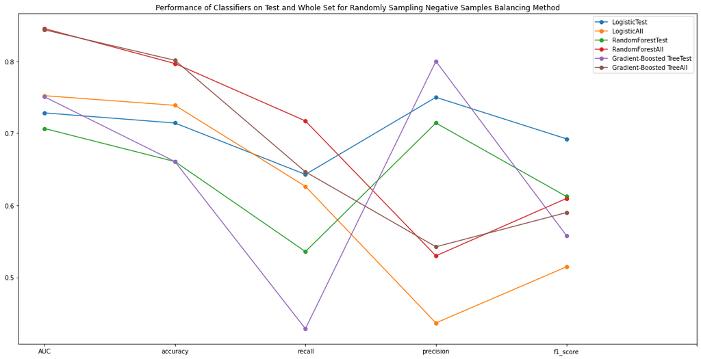

```python
#Plot the result of model_metrics using balancing method 1 => Random sampling negative samples
plt.figure(figsize = [20,10])
model_metrics_table_neg.plot(kind ='line', marker = 'o', figsize = [20,10], xticks = [0,1,2,3,4,5], title = 'Performance of Classifiers on Test and Whole Set for Randomly Sampling Negative Samples Balancing Method')
```

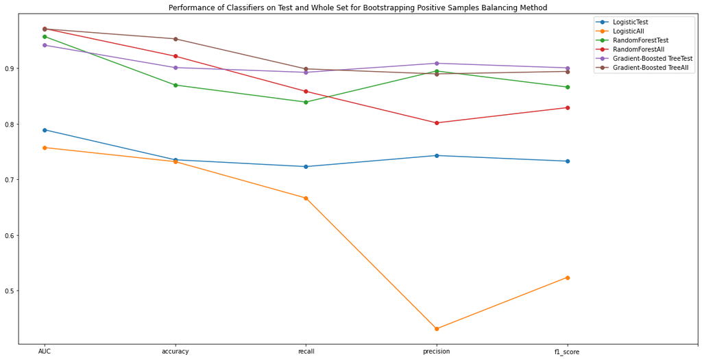

```python
#Plot the result of model_metrics using balancing method 2 => Bootstrap positive samples
plt.figure(figsize = [20,10])
model_metrics_table_pos.plot(kind ='line', marker = 'o', figsize = [20,10], xticks = [0,1,2,3,4,5], title = 'Performance of Classifiers on Test and Whole Set for Bootstrapping Positive Samples Balancing Method')
```

## Justification

Overall, Logistic Regression did the worst perhaps because we are analyzing human behavior which is not so linear.

Besides, the psosible possible reasons for gradient-boosted tree to get overfitted so easily is that the algorithm is iterative and greedy, as we only have little amount of data, it's easy to get overfitted.

The major problem causing overall failure in whole set in my opinion is due to dataset size, because the amount of data is not enough to represent population, the model could easily get biased.

### Logistic Regression-Coefficient

In this part, we analyzed the contribution of features by coefficient

#### Randomly Sampling Negative Samples Balancing Method

[output not shown]

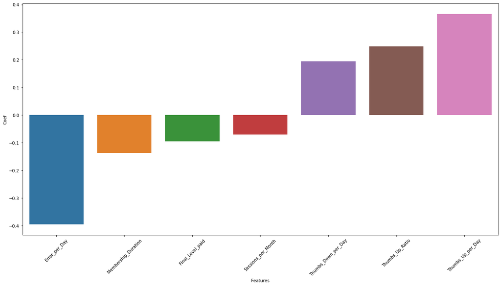

```python
#Retrieve coefficient information from LR Model using Randomly Sampling Negative Samples Balancing Method
LR_Coef_neg = lrModel_neg.bestModel.coefficients
LR_Coef_Table_neg = pd.DataFrame({"Features": feature_columns, "Coef":LR_Coef_neg})
LR_Coef_Table_neg.sort_values(by = 'Coef', inplace = True)
plt.figure(figsize = [20,10])
sb.barplot(x = 'Features', y = 'Coef', data = LR_Coef_Table_neg)
plt.xticks(rotation = 45)
```

#### Bootstrapping Positive Sampling Balancing Method

[output not shown]

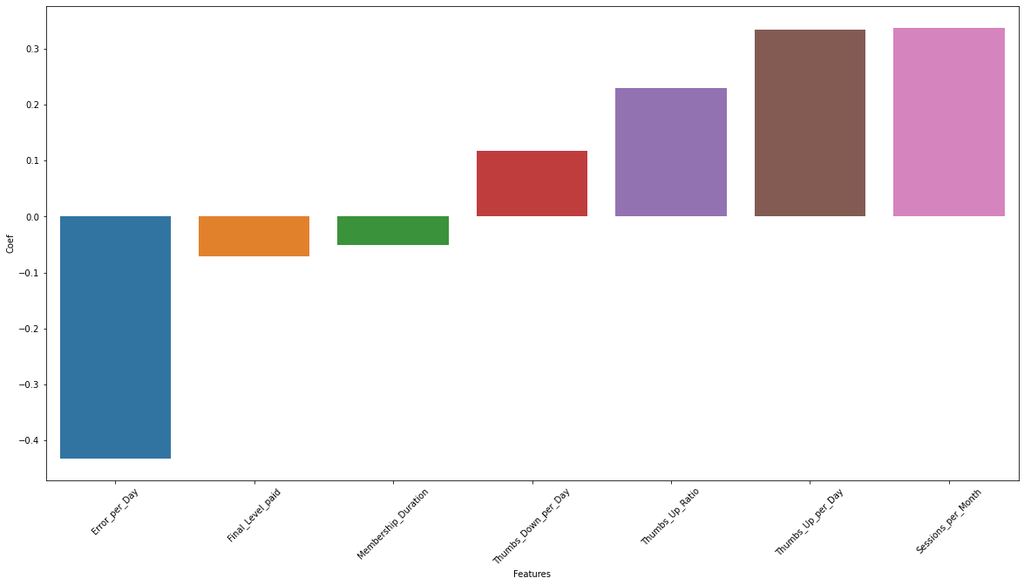

```python
#Retrieve coefficient information from LR Model using Bootstrapping Positive Sampling Balancing Method
LR_Coef_pos = lrModel_pos.bestModel.coefficients
LR_Coef_Table_pos = pd.DataFrame({"Features": feature_columns, "Coef":LR_Coef_pos})
LR_Coef_Table_pos.sort_values(by = 'Coef', inplace = True)
plt.figure(figsize = [20,10])
sb.barplot(x = 'Features', y = 'Coef', data = LR_Coef_Table_pos)
plt.xticks(rotation = 45)
```

### RandomForest Importance

In this part, we analyzed the contribution of features by importance

#### Randomly Sampling Negative Samples Balancing Method

[output not shown]

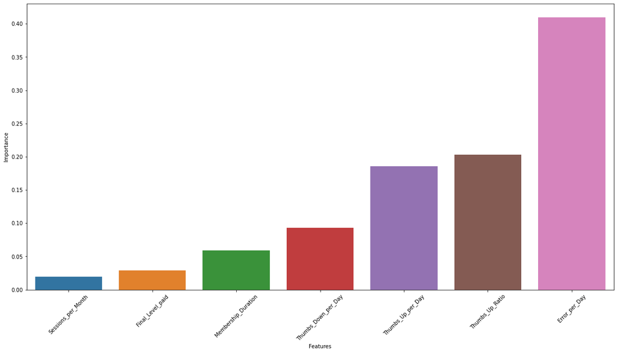

```python
#Retrive feature importance from Random Forest model using Randomly Sampling Negative Samples Balancing Method
RFC_Importance_neg = rfcModel_neg.bestModel.featureImportances
RFC_Importance_Table_neg = pd.DataFrame({"Features": feature_columns, "Importance":RFC_Importance_neg})
RFC_Importance_Table_neg.sort_values(by = 'Importance', inplace = True)
plt.figure(figsize = [20,10])
sb.barplot(x = 'Features', y = 'Importance', data = RFC_Importance_Table_neg)
plt.xticks(rotation = 45)
```

#### Bootstrapping Positive Sampling Balancing Method

[output not shown]

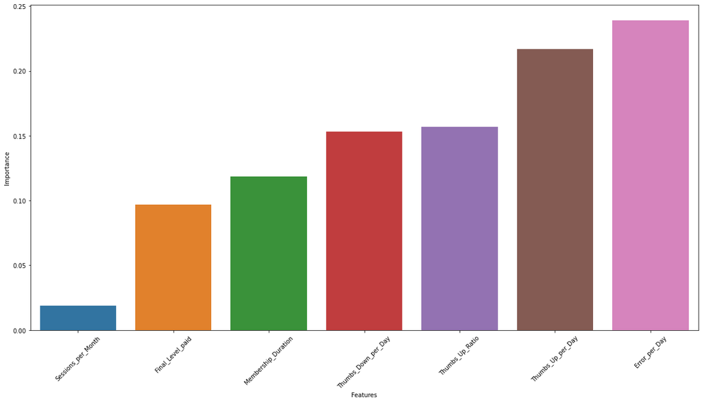

```python
#Retrive feature importance from Random Forest model using Bootstrapping Positive Sampling Balancing Method
RFC_Importance_pos = rfcModel_pos.bestModel.featureImportances
RFC_Importance_Table_pos = pd.DataFrame({"Features": feature_columns, "Importance":RFC_Importance_pos})
RFC_Importance_Table_pos.sort_values(by = 'Importance', inplace = True)
plt.figure(figsize = [20,10])
sb.barplot(x = 'Features', y = 'Importance', data = RFC_Importance_Table_pos)
plt.xticks(rotation = 45)
```

### Gradient-Boosted Tree Importance

In this part, we analyzed the contribution of features by importance

#### Randomly Sampling Negative Samples Balancing Method

[output not shown]

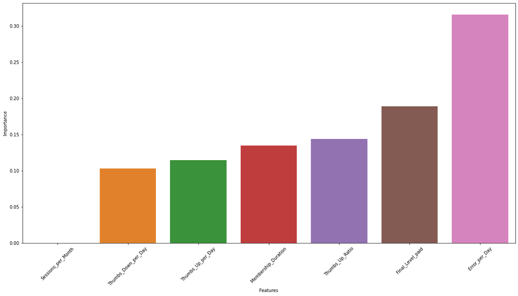

```python
#Retrive feature importance from Gradient-Boosted Tree model using Randomly Sampling Negative Samples Balancing Method
GBT_Importance_neg = gbtModel_neg.bestModel.featureImportances
GBT_Importance_Table_neg = pd.DataFrame({"Features": feature_columns, "Importance":GBT_Importance_neg})
GBT_Importance_Table_neg.sort_values(by = 'Importance', inplace = True)
plt.figure(figsize = [20,10])
sb.barplot(x = 'Features', y = 'Importance', data = GBT_Importance_Table_neg)
plt.xticks(rotation = 45)
```

#### Bootstrapping Positive Sampling Balancing Method

[output not shown]

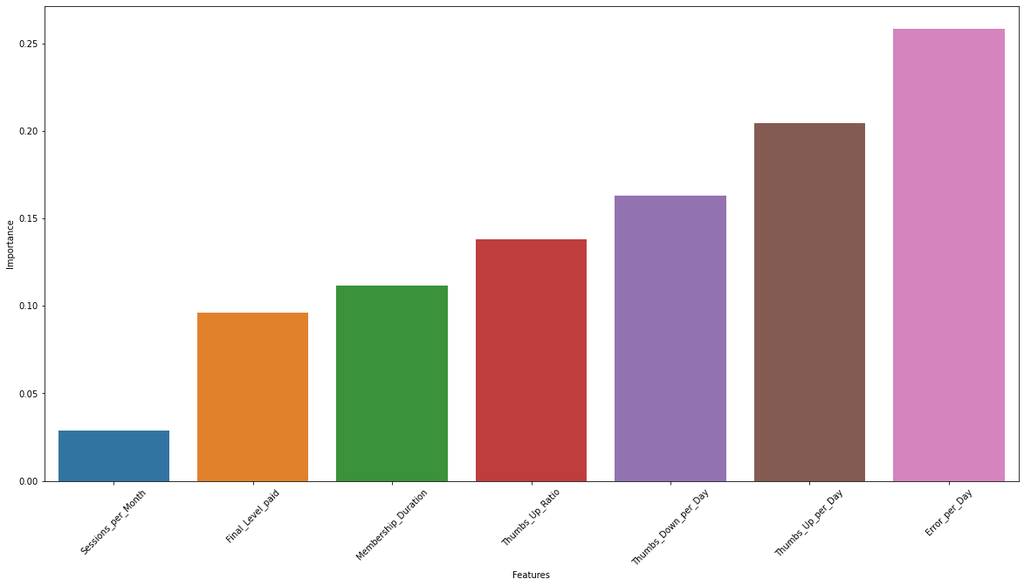

```python
#Retrive feature importance from Gradient-Boosted Tree model using Bootstrapping Positive Sampling Balancing Method
GBT_Importance_pos = gbtModel_pos.bestModel.featureImportances
GBT_Importance_Table_pos = pd.DataFrame({"Features": feature_columns, "Importance":GBT_Importance_pos})
GBT_Importance_Table_pos.sort_values(by = 'Importance', inplace = True)
plt.figure(figsize = [20,10])
sb.barplot(x = 'Features', y = 'Importance', data = GBT_Importance_Table_pos)
plt.xticks(rotation = 45)
```

# Conclusion

Blog Post of this project can be found here  
https://burgercewu.medium.com/never-lose-any-one-sparkify-user-churn-prediction-challenge-using-pyspark-7ab67ac080d4  
Github Repository can be found here  
https://github.com/BurgerWu/Sparkify-Project